# ETS ~ Lichtgradient

Johannes Osewold

2023-05-23

## ETS ~ Lichtgradient

Zunächst schaue ich mir mal an wie denn der ETS Anteil räumlich verteilt ist. Für Lauenburg und Göttingen. Die Plotgröße ist die Anzahl Bäume pro Plot.

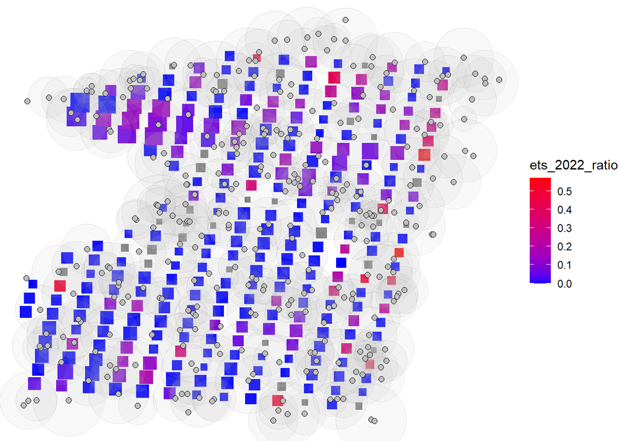

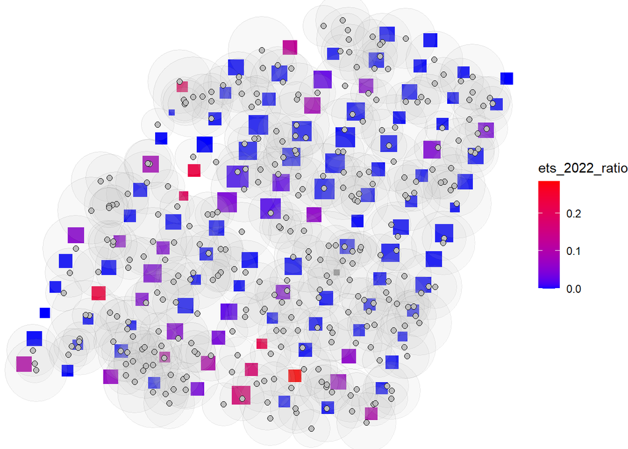

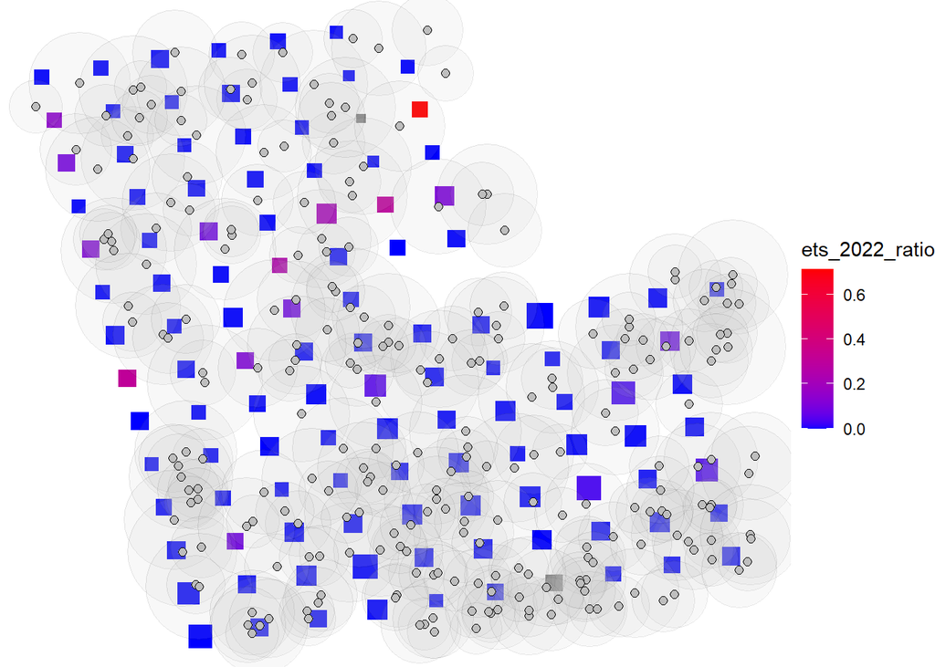

Anschließend wird der Total Site Factor als Plotgröße dargestellt.

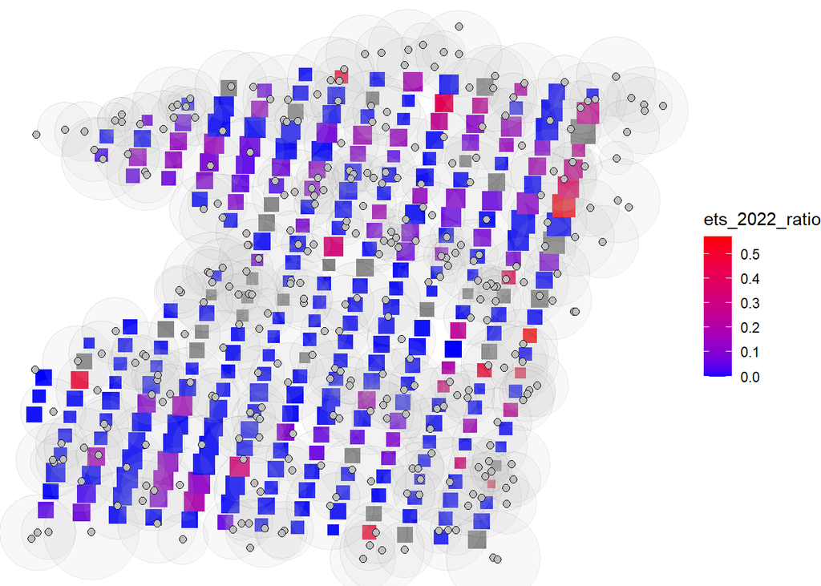

Jetzt gibt es aber das Problem, dass die Plots mit sehr wenig Eschen aber davon 50% ETS die Verteilung in einem Diagramm massiv verschieben, daher folgt hier ein Versuch die Plots zusätzlich nach ihren absoluten Eschenmengen zu gewichten. Es wäre natürlich auch denkbar nur die absoluten ETS Zahlen zu verwenden, aber dann würden wieder Plots mit 100 Eschen und 10 ETS stärker ausfallen als plots mit 10 zu 3.

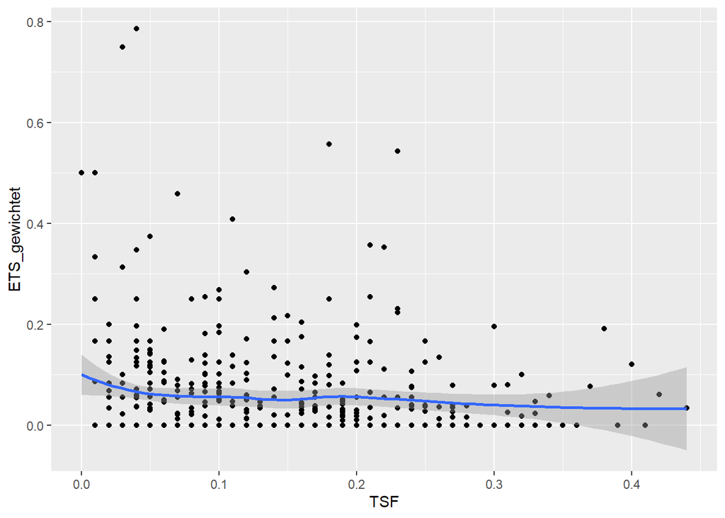

Ich habe festgestellt das meine Gewichtung beim ersten Versuch dumm war. Statt dessen werden nun die Plots die ein hohes statistisches Gewicht haben mehrfach gezählt, sie kommen also einfach öfter vor. Die Range wird im folgenden ebenfalls ausgegeben. Und nur der Vollständigkeit halber werden alle nuller im zweiten Diagramm entfernt obwohl natürlich klar ist, dass das nicht korrekt wäre.

```
## [1]  0 10
```

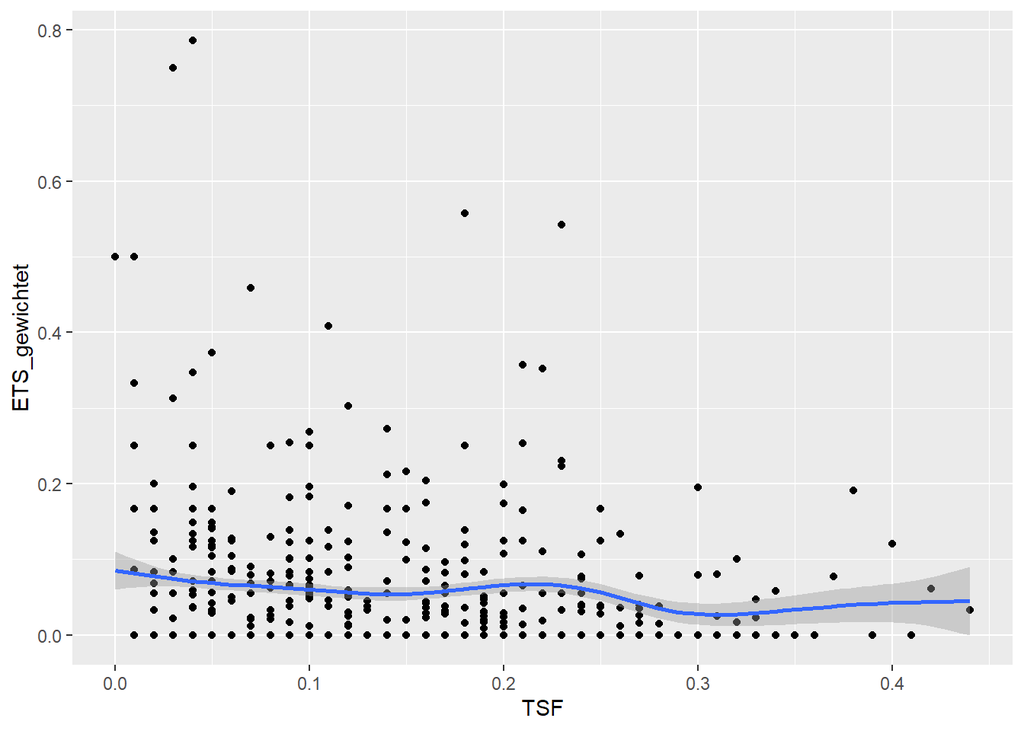

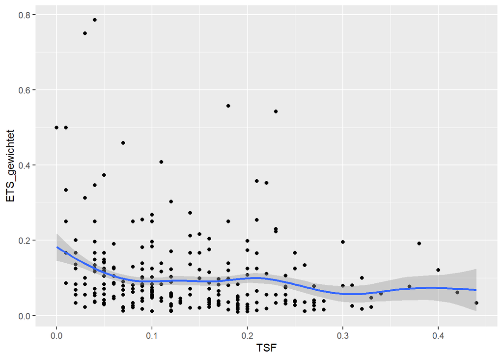

FAZIT

Es gibt wohl einfach keinen relevanten Zusammenhang.